# Prediction project

Balsher Singh

April 28, 2017

### Summary

[output not shown]

```r
set.seed(333)
```

### Data Exploration

Load data and check its structure

```r
train <- read.csv(url("https://d396qusza40orc.cloudfront.net/predmachlearn/pml-training.csv"))

test <- read.csv(url("https://d396qusza40orc.cloudfront.net/predmachlearn/pml-testing.csv"))
str(train)
```

[output not shown]

#### Data cleaning

There are several columns that are empty or contain all N/A values.

```r
t2 <- train[,!(sapply(train, function(x) sum(is.na(x)))==19216)]
t2 <- t2[,!sapply(t2, function(x) sum(x=="")==19216)]
```

In t2, I have saved the training data after removing all such columns.

```r
str(t2)
```

[output not shown]

I see that there is a date/time column

```r
t2$cvtd_timestamp <- as.Date(x = t2$cvtd_timestamp, format = "%d/%m/%Y %H:%M")
```

#### Data slicing

I leave aside the 20 observation saved in the `test` variable and partition the training set into train, ‘t3’ and validation, ‘t4’ sets to the proportion of 75/25 respectively, note we use the ‘classe’ variable.

```r
library(caret)
intrain <- createDataPartition(train$classe, p = 0.75, list = FALSE)
t3 <- t2[intrain,]
t4 <- t2[-intrain,]
```

#### Continue exploration with the in training data

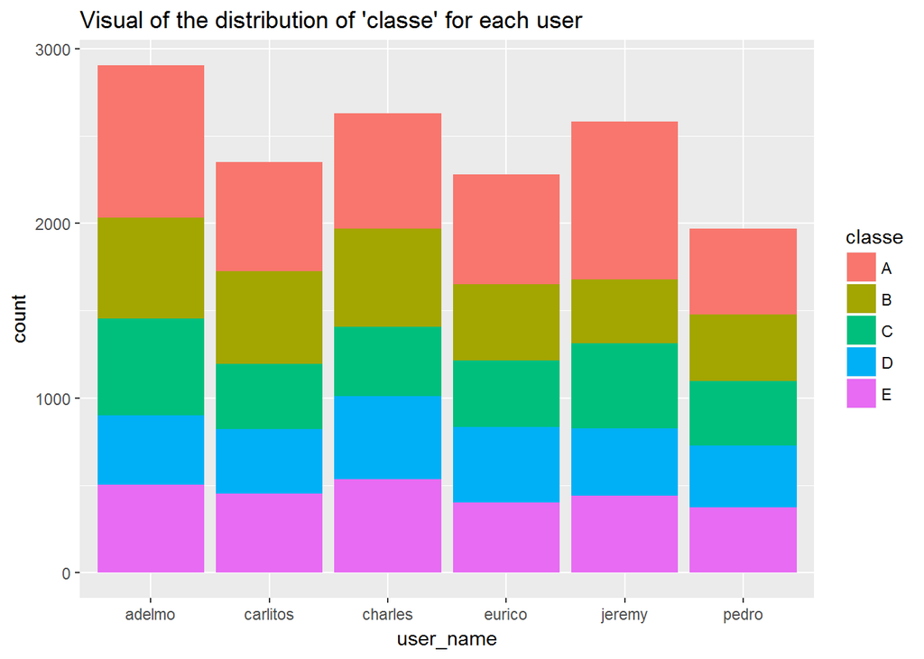

```r
library(ggplot2)
ggplot(t3, aes(x=user_name, fill = classe)) + geom_histogram(stat="count") + ggtitle("Visual of the distribution of 'classe' for each user")
```

#### Principal component analysis

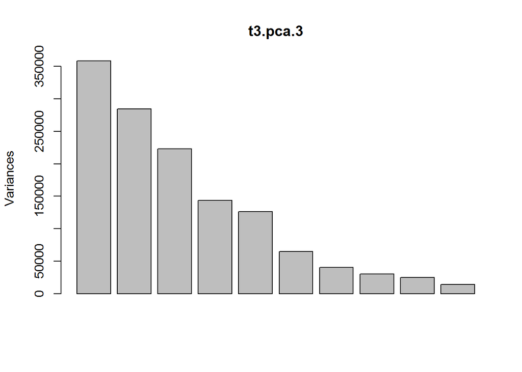

```r
t3.pca.3 <- prcomp(t3[-c(1,2,3,4,5,6,7,60)])
plot(t3.pca.3)
```

```r
with_pca <- rownames(t3.pca.3$rotation)
head(with_pca)
```

```
## [1] "roll_belt"        "pitch_belt"       "yaw_belt"
## [4] "total_accel_belt" "gyros_belt_x"     "gyros_belt_y"
```

### Model fitting

```r
library(caret)
library(rattle)
id.fit1 <- c(with_pca[1:15],names(t3)[60])
fit1 <- train(classe ~ . , method = 'rpart', data = t3[id.fit1])
```

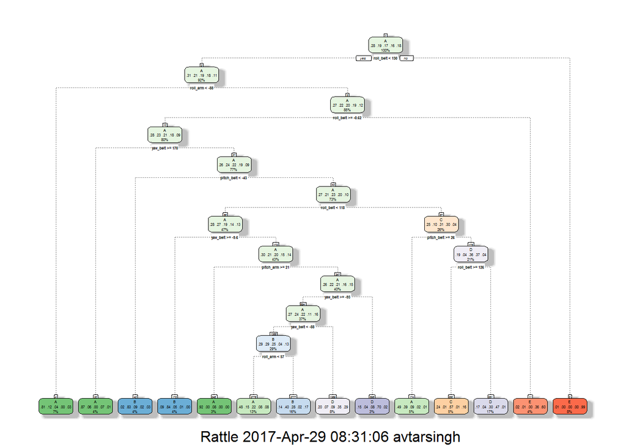

```r
fancyRpartPlot(fit1$finalModel)
```

Predict and check its Accuracy

```r
pred1 <- predict(fit1, newdata = t4[id.fit1])
pred1.c <- confusionMatrix(pred1, t4$classe)
pred1.c$overall['Accuracy']
```

```
##  Accuracy
## 0.5858483
```

There is not enough accuracy in this model.

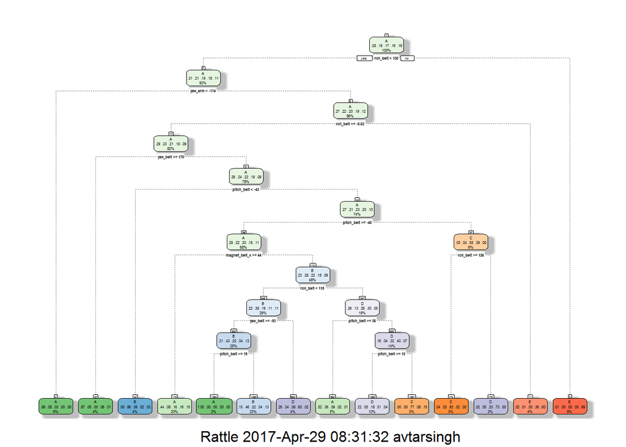

```r
id.fit2 <- c(with_pca[1:20],names(t3)[60])
fit2 <- train(classe ~ . , method = 'rpart', data = t3[id.fit2])
fancyRpartPlot(fit2$finalModel)
```

```r
pred2 <- predict(fit2, newdata = t4[id.fit2])
pred2.c <- confusionMatrix(pred2, t4$classe)
pred2.c$overall['Accuracy']
```

```
##  Accuracy
## 0.6115416
```

Still the accuracy has has not improved enough, with Decision Trees method accuracy dose not go above 61%.

#### Random Forest

```r
library(randomForest)
fit.rf <- randomForest(classe ~ ., data = t3[c(with_pca,names(t3)[60])])
pred.rf <- predict(fit.rf, t4)
pred.rf.c <- confusionMatrix(pred.rf, t4$classe)
pred.rf.c$table
```

```
##           Reference
## Prediction    A    B    C    D    E
##          A 1394    4    0    0    0
##          B    0  942    6    0    0
##          C    0    3  848    8    1
##          D    0    0    1  796    1
##          E    1    0    0    0  899
```

This is confusin Matrix is acceptable and will be chossen as the final model.

Apply the final model on test dataset

```r
testset <- test[, names(test) %in% names(t3[c(with_pca,names(t3)[60])])]



predict(fit.rf, testset)
```

```
##  1  2  3  4  5  6  7  8  9 10 11 12 13 14 15 16 17 18 19 20
##  B  A  B  A  A  E  D  B  A  A  B  C  B  A  E  E  A  B  B  B
## Levels: A B C D E
```